## **Western barred bandicoot**

### Blamed on cats

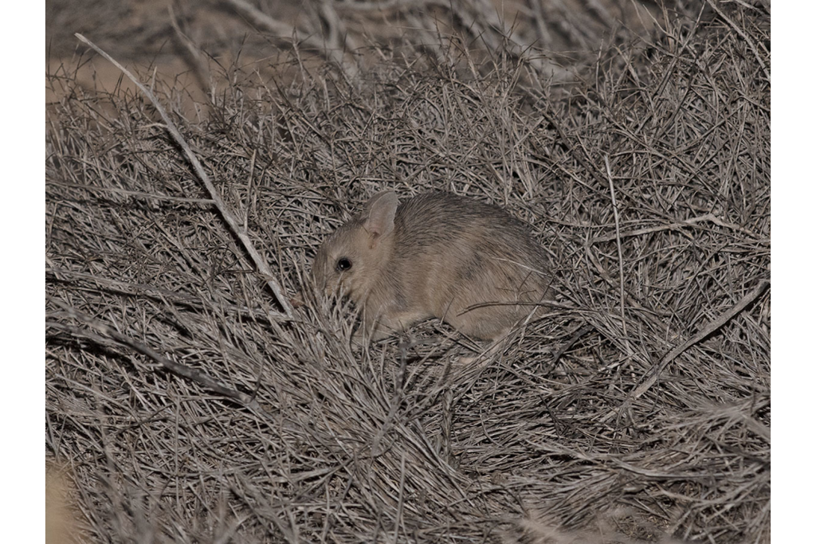

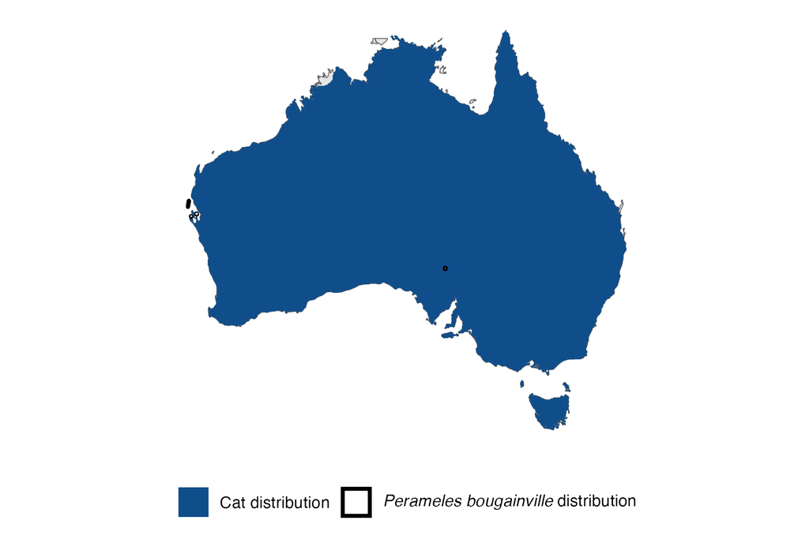

IUCN status: **Vulnerable**

EPBC Predator Threat Rating: **Moderate**

IUCN claim: *“The current major threats to the natural subpopulations of the species include: the accidental introduction of predators (introduced cats and foxes)”*

### Studies not in support

Bandicoots were reintroduced successfully into a fenced reserve with cats (defined as low density) and no evidence of predation was recorded (Richards & Short 2003). Bandicoots were last confirmed in the Western Division of NSW 23 years before, to 27 years after, cats arrived (Wallach and Lundgren 2025).

### Is the threat claim evidence-based?

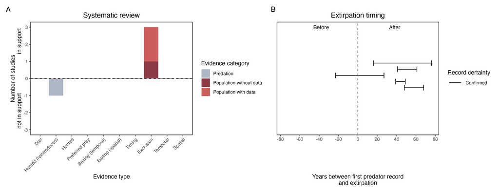

**Evidence linking *Perameles bougainville* to cats.** **A.** Systematic review of evidence for an association between *Perameles bougainville* and cats. Positive studies are in support of the hypothesis that cats contribute to the decline of *Perameles bougainville*, negative studies are not in support. Predation studies include studies documenting hunting or scavenging; baiting studies are associations between poison baiting and threatened mammal abundance where information on predator abundance is not provided; population studies are associations between threatened mammal and predator abundance. Gold borders indicate studies that meet qualities of scientific rigour. **B.** Last records of extirpated populations relative to earliest local records of cats. Error bars show minimum and maximum extinction intervals. Predator arrival records were digitized from Abbott 2008. See methods section in Wallach and Lundgren 2025 for details on evidence categories.

### References

Abbott, The spread of the cat, Felis catus, in Australia: re-examination of the current conceptual model with additional information. Conservation Science Western Australia 7 (2008).

EPBC. (2015) Threat Abatement Plan for Predation by Feral Cats. Environment Protection and Biodiversity Conservation Act 1999, Department of Environment, Government of Australia. (Table A1).

IUCN Red List. https://www.iucnredlist.org/ Accessed June 2023

Richards, J., 2012. Western barred bandicoot Perameles bougainville, burrowing bettong Bettongia lesueur and banded hare-wallaby Lagostrophus fasciatus National Recovery Plan. Wildlife Management Program, (49).

Richards, J.D. and Short, J., 2003. Reintroduction and establishment of the western barred bandicoot Perameles bougainville (Marsupialia: Peramelidae) at Shark Bay, Western Australia. Biological Conservation, 109(2), pp.181-195.

Short, J., 2016. Predation by feral cats key to the failure of a long-term reintroduction of the western barred bandicoot (Perameles bougainville). Wildlife Research, 43(1), pp.38-50.

Wallach A.D., Lundgren E.J. (2025) Review of evidence that foxes and cats cause extinctions of Australia’s endemic mammals. BioScience. DOI: 10.1093/biosci/biaf046